# laptop_prices_analysis_DA_Project

# Column Touchscreen and prices_euros

```
<function matplotlib.pyplot.show(close=None, block=None)>
```

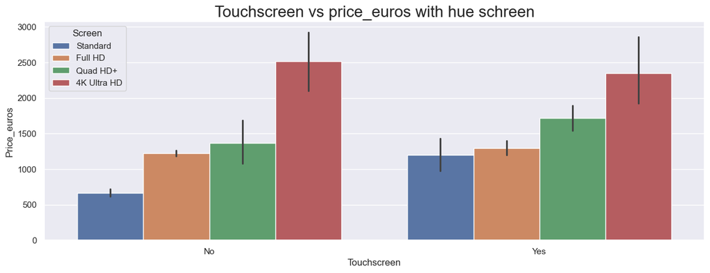

```python
sns.set(rc={'figure.figsize':(15,5)})
sns.barplot(x=df['Touchscreen'],y=df['Price_euros'],hue=df['Screen'])
plt.title("Touchscreen vs price_euros with hue schreen",fontsize=20)

plt.show
```

#### Standard resolution laptops remain the most affordable option, regardless of touchscreen availability.

#### Error bars suggest price variations within each category, especially for higher resolutions like 4K Ultra HD, where premium models contribute to the wider price range.

# Column screen and prices_euros

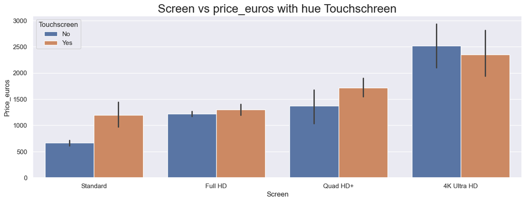

```python
sns.set(rc={'figure.figsize':(15,5)})
sns.barplot(x=df['Screen'],y=df['Price_euros'],hue=df['Touchscreen'])
plt.title("Screen vs price_euros with hue Touchschreen",fontsize=20)

plt.show()
```

###### here are some insights from the bar plot:

##### Touchscreen laptops tend to be more expensive for lower resolutions – Standard and Quad HD+ screens show a noticeable price increase for touchscreen models.

##### For Full HD and 4K Ultra HD, the price difference between touchscreen and non-touchscreen laptops is minimal, suggesting that touchscreen capability is less of a price determinant in premium models.

##### 4K Ultra HD laptops are the most expensive, with both touchscreen and non-touchscreen variants having the highest average prices.

# Column OS and prices_euros

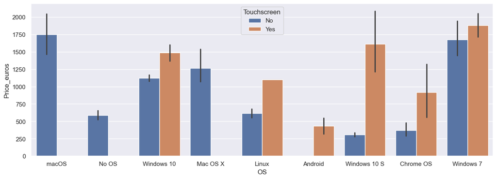

```python
plt.Figure(figsize=(10,4))
sns.barplot(x=df['OS'],y=df['Price_euros'],hue=df['Touchscreen'])

plt.show()
```

### Windows 10 S and Linux touchscreen laptops show a significant price increase, indicating premium models in these categories.

# Column Primarystorage and prices_euros

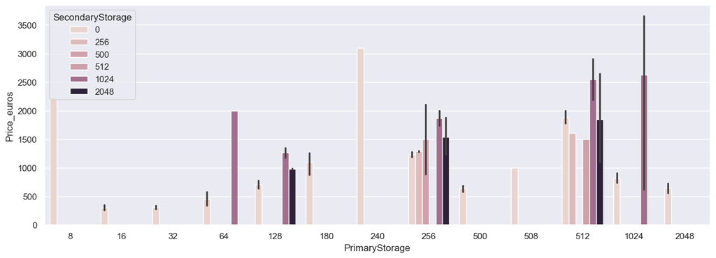

```python
plt.Figure(figsize=(10,4))
sns.barplot(x=df['PrimaryStorage'],y=df['Price_euros'],hue=df['SecondaryStorage'])

plt.show()
```

### Devices with no secondary storage tend to be more affordable, except in cases where high primary storage compensates for it.

### Significant price variations exist within the same primary storage category, indicating the influence of other premium features beyond just storage capacity

# Column retinaDisplay and prices_euros

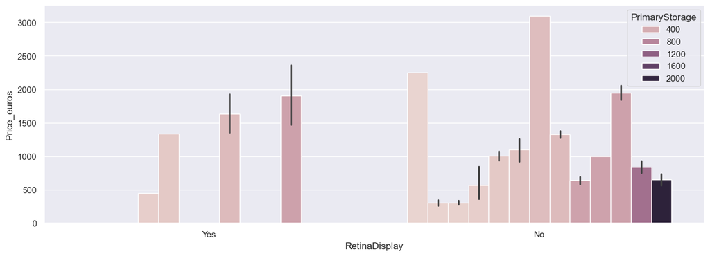

```python
#sns.set(rc={'figure.figsize':(15,5)})
sns.barplot(data=df,x=df['RetinaDisplay'],y=df['Price_euros'],hue=df['PrimaryStorage'])
plt.show()
```

### The price difference between Retina and non-Retina models is more noticeable at lower storage levels but evens out at higher storage capacities.

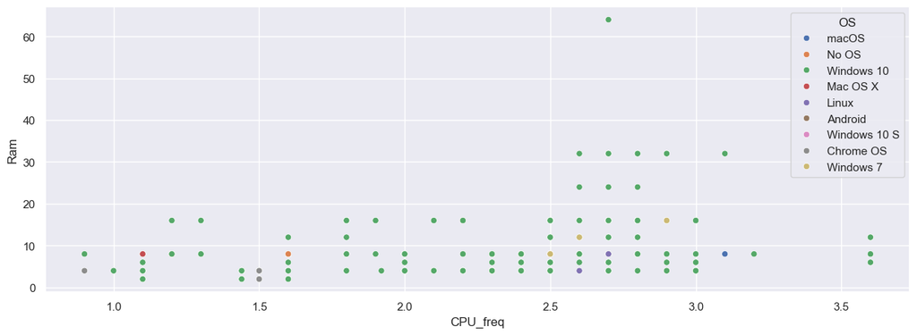

```python
sns.scatterplot(data = df , x= df['CPU_freq'], y =
df['Ram'], hue = df['OS'])
```

### Most laptops have CPU frequencies between 1.0 GHz and 3.0 GHz, with RAM capacities varying significantly within this range.

### igher RAM values (above 20GB) are found in laptops with CPU frequencies above 2.5 GHz, indicating high-performance machines.

### Windows 10 dominates the dataset, while Chrome OS and macOS appear in specific clusters, likely representing budget and premium devices, respectively.